# Week 10 Day 1 Homework

```r
library(tidyverse)
library(ggfortify)
library(modelr)
```

```r
pm <- read_csv("data/project_management.csv")
```

```
## ──────────────────────────────────────────────────────── Delimiter: "," dbl
## (3): ...1, estimated_length, actual_length
```

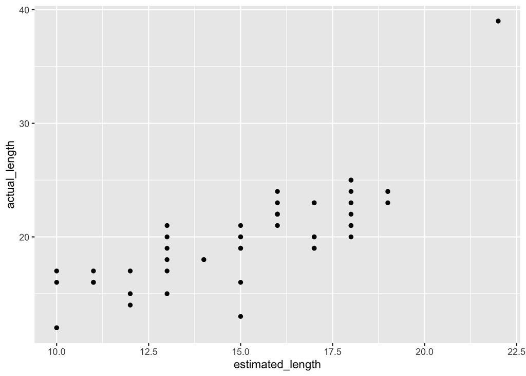

```r
pm %>%
  ggplot(aes(estimated_length, actual_length)) +
  geom_point()
```

```r
pm %>%
summarise(cor(estimated_length, actual_length))
```

| cor(estimated_length, actual_length) |
| --- |
| 0.8046597 |

The 2 variables are positively correlated. On the Evans strength of correlation scale this is a very strong correlation.

```r
model <- lm(actual_length ~ estimated_length, data = pm)

summary(model)
```

```
##
## Call:
## lm(formula = actual_length ~ estimated_length, data = pm)
##
## Residuals:
##     Min      1Q  Median      3Q     Max
## -6.7687 -1.6513  0.1195  1.1252 10.6669
##
## Coefficients:
##                  Estimate Std. Error t value Pr(>|t|)
## (Intercept)        1.4164     2.0069   0.706    0.484
## estimated_length   1.2235     0.1303   9.389 1.91e-12 ***
## ---
## Signif. codes:  0 '***' 0.001 '**' 0.01 '*' 0.05 '.' 0.1 ' ' 1
##
## Residual standard error: 2.606 on 48 degrees of freedom
## Multiple R-squared:  0.6475, Adjusted R-squared:  0.6401
## F-statistic: 88.16 on 1 and 48 DF,  p-value: 1.911e-12
```

```r
fitted(model)
```

```
##        1        2        3        4        5        6        7        8
## 16.09825 20.99220 20.99220 23.43918 28.33313 24.66267 23.43918 23.43918
##        9       10       11       12       13       14       15       16
## 23.43918 19.76871 19.76871 20.99220 16.09825 18.54522 14.87476 17.32173
##       17       18       19       20       21       22       23       24
## 22.21569 19.76871 14.87476 23.43918 22.21569 17.32173 19.76871 13.65127
##       25       26       27       28       29       30       31       32
## 22.21569 17.32173 20.99220 17.32173 14.87476 20.99220 13.65127 24.66267
##       33       34       35       36       37       38       39       40
## 17.32173 17.32173 16.09825 13.65127 23.43918 23.43918 13.65127 20.99220
##       41       42       43       44       45       46       47       48
## 22.21569 22.21569 18.54522 23.43918 20.99220 19.76871 24.66267 19.76871
##       49       50
## 22.21569 19.76871
```

slope = 1.2234 intercept = 1.4164 R2 = 0.6475

The R2 value tells us that 64.75% of the data can be predicted with the model

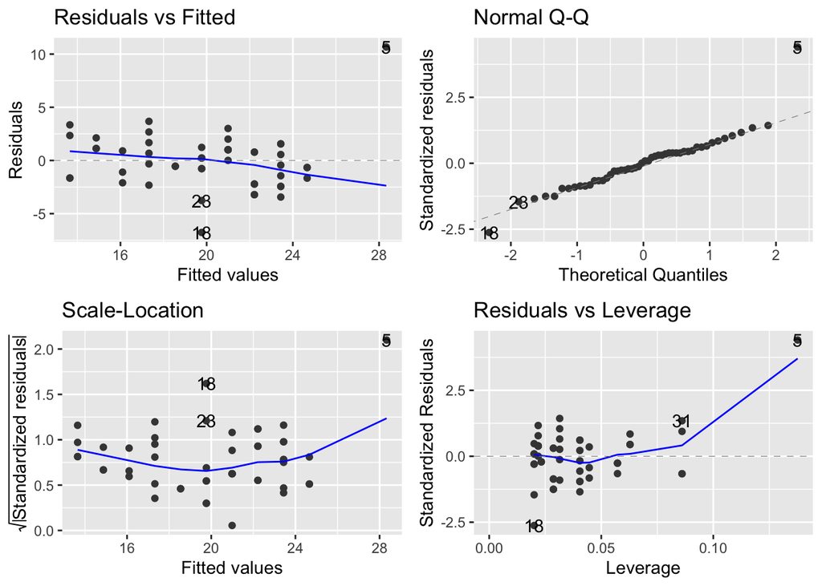

```r
autoplot(model)
```

1. Residual vs fitted - doesn’t look good at high values
2. QQ - looks ok but one outlier at top end
3. Scale - Location - possibly a funnel shape

The plots suggest that the p-value is not reliable.

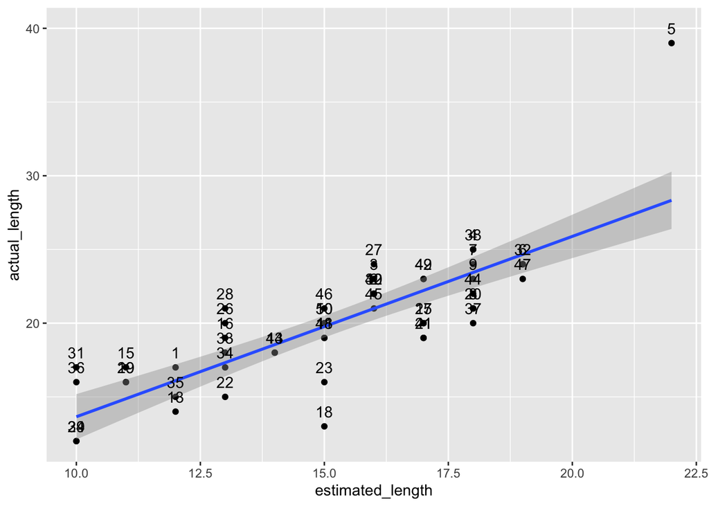

```r
pm %>%
  ggplot(aes(estimated_length, actual_length)) +
  geom_point() +
  geom_smooth(method = "lm") +
  geom_text(aes(label = 1:nrow(pm)), nudge_y = 1)
```

outliers = 5 and 18 and possibly 23

5 is influential 23 is not influential and 18 is not influential

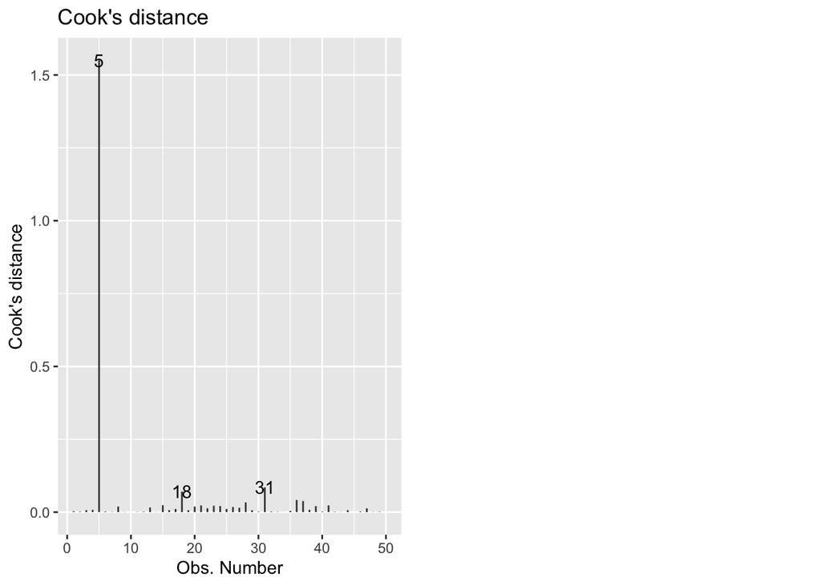

```r
autoplot(model, which = 4)
```

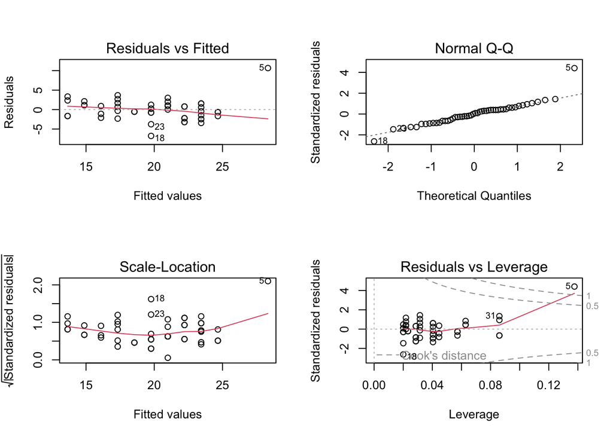

```r
par(mfrow = c(2,2))
plot(model)
```

```r
pm_without_18 <- pm %>%
  filter(!(estimated_length == 15 & actual_length == 13))
```

```r
model_wo18 <- lm(actual_length ~ estimated_length, data = pm_without_18)

summary(model_wo18)
```

```
##
## Call:
## lm(formula = actual_length ~ estimated_length, data = pm_without_18)
##
## Residuals:
##     Min      1Q  Median      3Q     Max
## -3.9072 -1.7915  0.0928  0.9771 10.5453
##
## Coefficients:
##                  Estimate Std. Error t value Pr(>|t|)
## (Intercept)        1.5911     1.8782   0.847    0.401
## estimated_length   1.2211     0.1219  10.019 3.02e-13 ***
## ---
## Signif. codes:  0 '***' 0.001 '**' 0.01 '*' 0.05 '.' 0.1 ' ' 1
##
## Residual standard error: 2.438 on 47 degrees of freedom
## Multiple R-squared:  0.6811, Adjusted R-squared:  0.6743
## F-statistic: 100.4 on 1 and 47 DF,  p-value: 3.015e-13
```

Previous Results slope = 1.2234 intercept = 1.4164 R2 = 0.6475

without point 18 results slope = 1.2211 intercept = 1.5911 R2 = 0.6811

The R2 has improved a bit, the gradient isn’t much different but the intercept is higher.

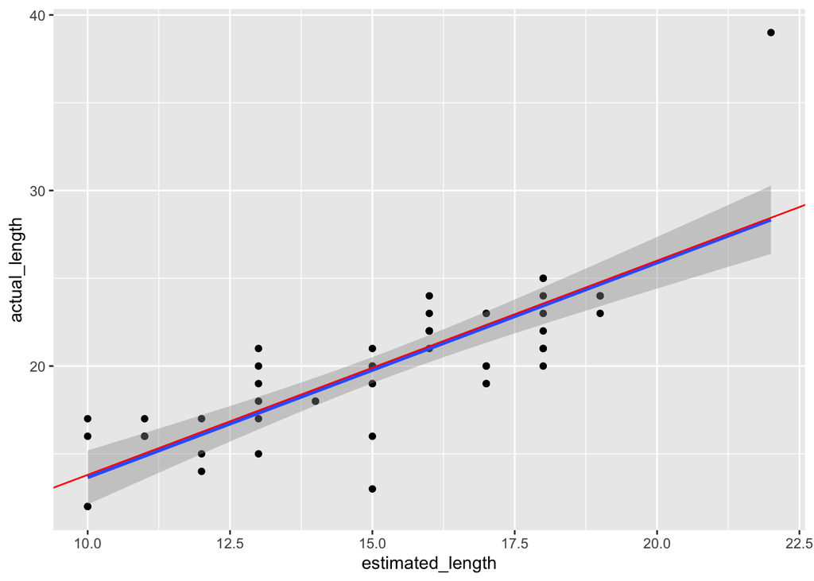

```r
ggplot(pm, aes(estimated_length, actual_length)) +
  geom_point() +
  geom_smooth(method = "lm") +
  geom_abline(slope = 1.2211, intercept = 1.5911, colour = "red")
```

```r
pm_without_5 <- pm %>%
  filter(!(estimated_length == 22 & actual_length == 39))
```

```r
model_wo5 <- lm(actual_length ~ estimated_length, data = pm_without_5)

summary(model_wo5)
```

```
##
## Call:
## lm(formula = actual_length ~ estimated_length, data = pm_without_5)
##
## Residuals:
##     Min      1Q  Median      3Q     Max
## -6.5510 -1.5737  0.4376  1.4376  3.4717
##
## Coefficients:
##                  Estimate Std. Error t value Pr(>|t|)
## (Intercept)        4.3806     1.6504   2.654   0.0108 *
## estimated_length   1.0114     0.1083   9.338 2.79e-12 ***
## ---
## Signif. codes:  0 '***' 0.001 '**' 0.01 '*' 0.05 '.' 0.1 ' ' 1
##
## Residual standard error: 2.032 on 47 degrees of freedom
## Multiple R-squared:  0.6498, Adjusted R-squared:  0.6423
## F-statistic: 87.19 on 1 and 47 DF,  p-value: 2.787e-12
```

All Data Results slope = 1.2234 intercept = 1.4164 R2 = 0.6475

without point 5 results slope = 1.0114 intercept = 4.3806 R2 = 0.6498498

The R2 has improved a bit compared to the R2 for all the data but it is not as good as the R2 for the data with point 18 removed.

The gradient is less steep which makes sense as we have removed a point which has high on the y-axis.

The intercept is higher.

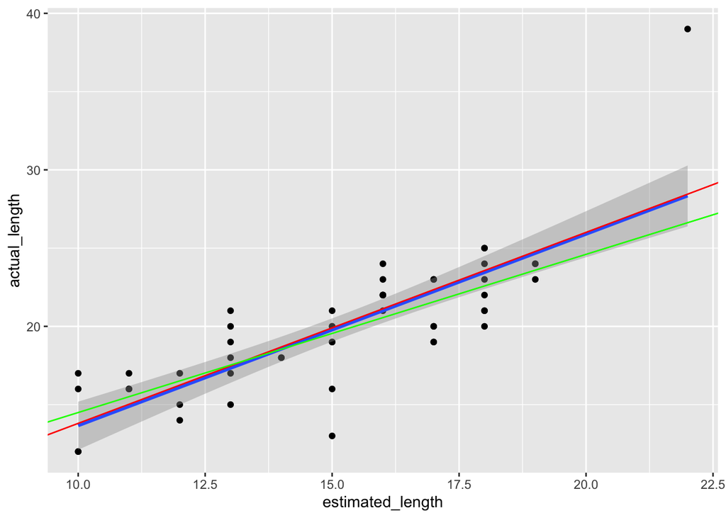

```r
ggplot(pm, aes(estimated_length, actual_length)) +
  geom_point() +
  geom_smooth(method = "lm") +
  geom_abline(slope = 1.2211, intercept = 1.5911, colour = "red") +
  geom_abline(slope = 1.0114, intercept = 4.3806, colour = "green")
```

```r
library(MASS)
```

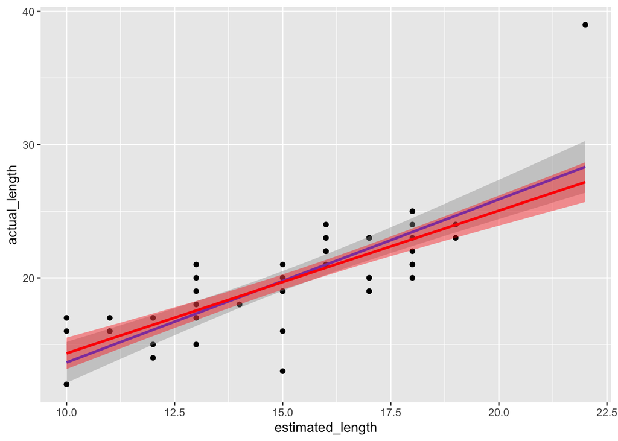

```r
ggplot(pm, aes(estimated_length, actual_length)) +
  geom_point() +
  geom_smooth(method = "lm") +
  geom_smooth(method = "rlm", colour = "red", fill = "red")
```

```r
model <-  rlm(actual_length ~ estimated_length, data = pm)

summary(model)
```

```
##
## Call: rlm(formula = actual_length ~ estimated_length, data = pm)
## Residuals:
##     Min      1Q  Median      3Q     Max
## -6.6884 -1.7415  0.2762  1.2408 11.8158
##
## Coefficients:
##                  Value   Std. Error t value
## (Intercept)       3.6259  1.6432     2.2066
## estimated_length  1.0708  0.1067    10.0371
##
## Residual standard error: 2.05 on 48 degrees of freedom
```

```r
library(broom)
tidy(model)
```

| term | estimate | std.error | statistic |
| --- | --- | --- | --- |
| (Intercept) | 3.625910 | 1.6431899 | 2.206629 |
| estimated_length | 1.070832 | 0.1066871 | 10.037120 |

```r
glance(model)
```

| sigma | converged | logLik | AIC | BIC | deviance | nobs |
| --- | --- | --- | --- | --- | --- | --- |
| 2.049521 | TRUE | -118.5637 | 243.1273 | 248.8634 | 335.8594 | 50 |